# Locale Analysis

Janette Avelar

5/18/2022

# Cycle 3 (5.18.22)

Guiding questions/tasks & format:  
`LOCALE`: How do tagging patterns differ among rural, urban, and suburban schools?  
* table of biggest differences between categories (urban vs. rural; rural vs. suburban; suburban vs. urban)  
* odds ratio  
* visualization

## Analysis Notes

Data used:  
There are 4 schools not included in analysis:  
* Horizons Alternative (no NCES/self-reported data)  
* Iowa Big (multi-coded locale)  
* The Forest Schools (multi-coded locale)  
* Link Learning (multi-coded locale)

Variables created:  
* `n` - number of schools that selected tag  
* `total_tags_locale` - total number of tags in given locale category  
* `pct_school` - percentage of schools that selected tag (n/157)  
* `pct_total_tags` - percentage of total tags within each locale (n/total_tags_locale)

## Across Locale Table and Plots

The following table and plots present the data within locales as a function of the full dataset.

In other words, the denominator is 157 (161 total schools - 4 schools excluded from analysis either because of either missing or multi-coded data).

As a result, the bar charts are perhaps not easily compared and/or what we were aiming for, something I realized after creating them, but I left them in for us to look at in case there’s any other information they help give us, such as overall distribution of tags.

*Note:* I haven’t incorporated theming into the plots yet–I need to figure out how to download fonts and work with theming, which I am not super familiar with and ran out of time.

### Table - Tagging Differences by Locale (across all schools)

|  | Tag | Urban vs. Rural Difference | Urban vs. Suburban Difference | Suburban vs. Rural Difference | Pct. Tags (Urban) | Pct. Tags (Suburban) | Pct. Tags (Rural) | N Tags (Urban) | N Tags (Suburban) | N Tags (Rural) |
| --- | --- | --- | --- | --- | --- | --- | --- | --- | --- | --- |
| 1 | à la carte model | 2 % | 3 % | 1 % | 10 % | 7 % | 8 % | 15 | 11 | 12 |
| 2 | accommodations for all students | 32 % | 29 % | 3 % | 43 % | 14 % | 11 % | 68 | 22 | 18 |
| 3 | adaptive content | 20 % | 11 % | 9 % | 25 % | 14 % | 5 % | 40 | 22 | 8 |
| 4 | advancement on mastery | 17 % | 16 % | 1 % | 25 % | 10 % | 8 % | 40 | 15 | 13 |
| 5 | student advisories | 31 % | 27 % | 4 % | 41 % | 14 % | 10 % | 64 | 22 | 16 |
| 6 | anti-racist practices | 38 % | 31 % | 7 % | 41 % | 11 % | 4 % | 65 | 17 | 6 |
| 7 | career readiness assessments | 20 % | 13 % | 7 % | 27 % | 14 % | 7 % | 42 | 22 | 11 |
| 8 | deeper learning assessments | 34 % | 34 % | 0 % | 48 % | 14 % | 14 % | 76 | 22 | 22 |
| 9 | social-emotional skills assessments | 32 % | 29 % | 4 % | 44 % | 15 % | 11 % | 69 | 24 | 18 |
| 10 | blended learning | 28 % | 26 % | 2 % | 39 % | 13 % | 11 % | 62 | 21 | 18 |

[output cut: 62 more lines]

### Urban vs. Rural Barchart (Across)

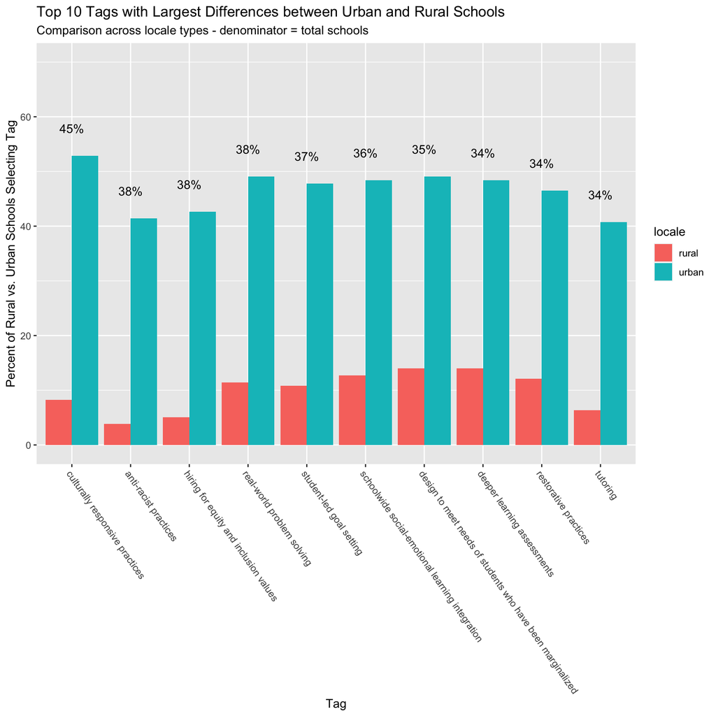

### Urban vs. Suburban Barchart (Across)

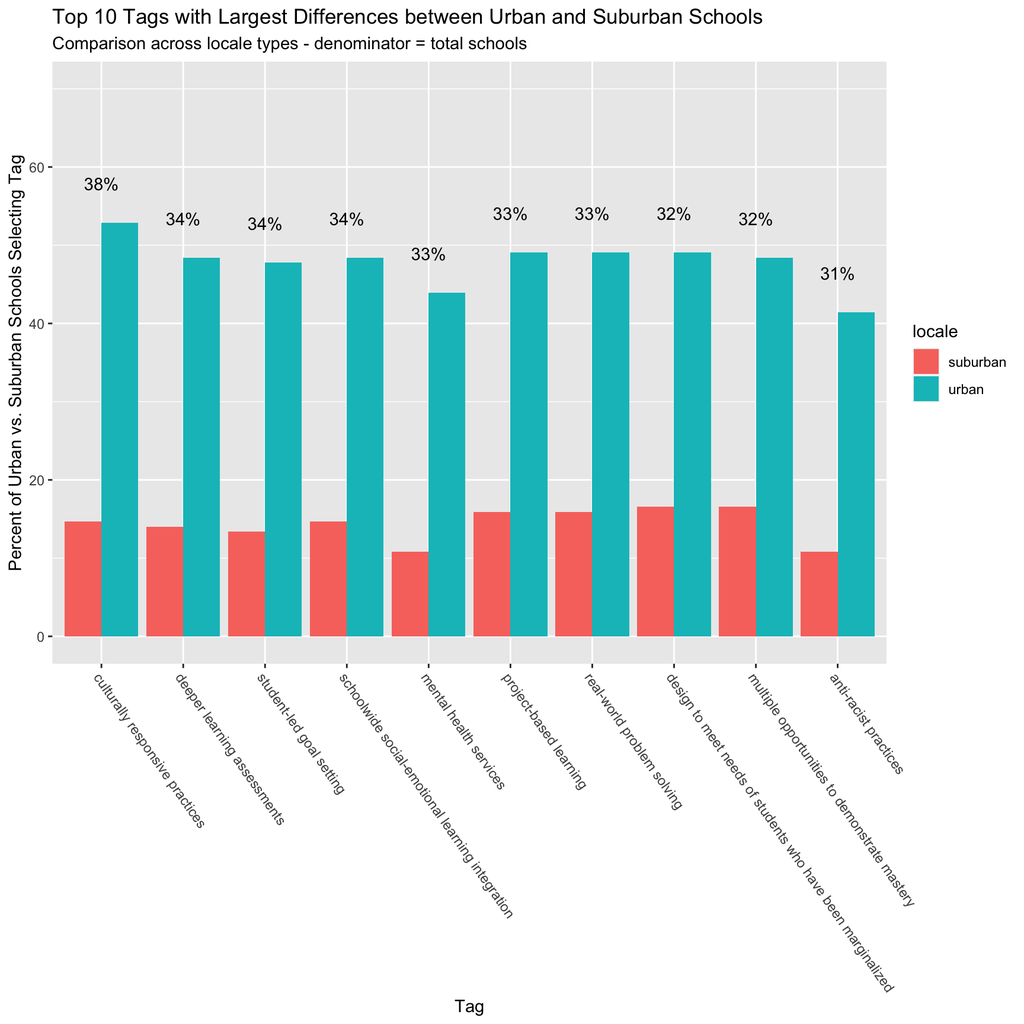

### Suburban vs. Rural Barchart (Across)

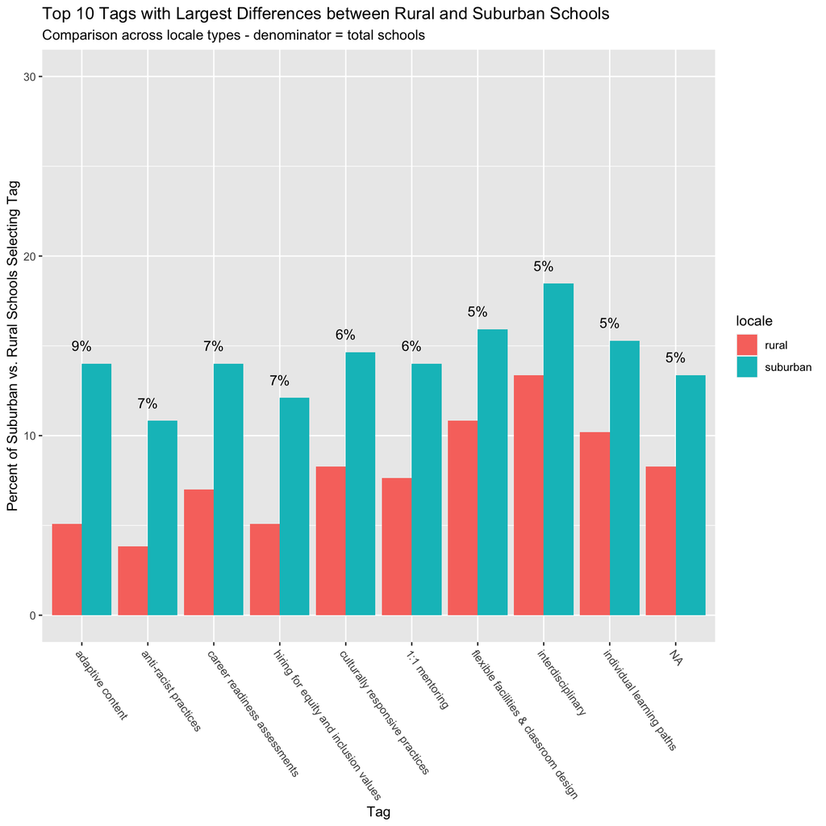

## Within Locale Table and Plots

In my second shot at plots, I’ve used tagging within locale as the basis for comparison. In other words, the denominator is equal to the number of schools within the specified locale type (95 urban schools, 32 suburban schools, and 30 rural schools = 157 total schools in analysis). This gives us an idea of the differences in tagging patterns within urban, suburban, and rural areas respectively, but I was hesitant to compare due to differences in sample size which is why I plan to also plot odds ratios in the third iteration of plotting below. Still useful to consider questions like, how much more often did suburban areas implement `x` practice than rural areas?

### Within Locale Table

|  | Tag | Urban vs. Rural Difference | Urban vs. Suburban Difference | Suburban vs. Rural Difference | Pct. Tags (Urban) | Pct. Tags (Suburban) | Pct. Tags (Rural) | N Tags (Urban) | N Tags (Suburban) | N Tags (Rural) |
| --- | --- | --- | --- | --- | --- | --- | --- | --- | --- | --- |
| 1 | à la carte model | 24 % | 19 % | 6 % | 16 % | 34 % | 40 % | 15 | 11 | 12 |
| 2 | accommodations for all students | 12 % | 3 % | 9 % | 72 % | 69 % | 60 % | 68 | 22 | 18 |
| 3 | adaptive content | 15 % | 27 % | 42 % | 42 % | 69 % | 27 % | 40 | 22 | 8 |
| 4 | advancement on mastery | 1 % | 5 % | 4 % | 42 % | 47 % | 43 % | 40 | 15 | 13 |
| 5 | student advisories | 14 % | 1 % | 15 % | 67 % | 69 % | 53 % | 64 | 22 | 16 |
| 6 | anti-racist practices | 48 % | 15 % | 33 % | 68 % | 53 % | 20 % | 65 | 17 | 6 |
| 7 | career readiness assessments | 8 % | 25 % | 32 % | 44 % | 69 % | 37 % | 42 | 22 | 11 |
| 8 | deeper learning assessments | 7 % | 11 % | 5 % | 80 % | 69 % | 73 % | 76 | 22 | 22 |
| 9 | social-emotional skills assessments | 13 % | 2 % | 15 % | 73 % | 75 % | 60 % | 69 | 24 | 18 |
| 10 | blended learning | 5 % | 0 % | 6 % | 65 % | 66 % | 60 % | 62 | 21 | 18 |

[output cut: 62 more lines]

### Urban vs. Rural (Within)

The biggest difference was shocking to me–68% of urban schools tagged anti-racist practices, compared to only 20% of rural schools (!!). Really curious to see how these top 3 (anti-racist practices, culturally-responsive practices, and hiring for equity and inclusion values) have or have not shifted from previous years.

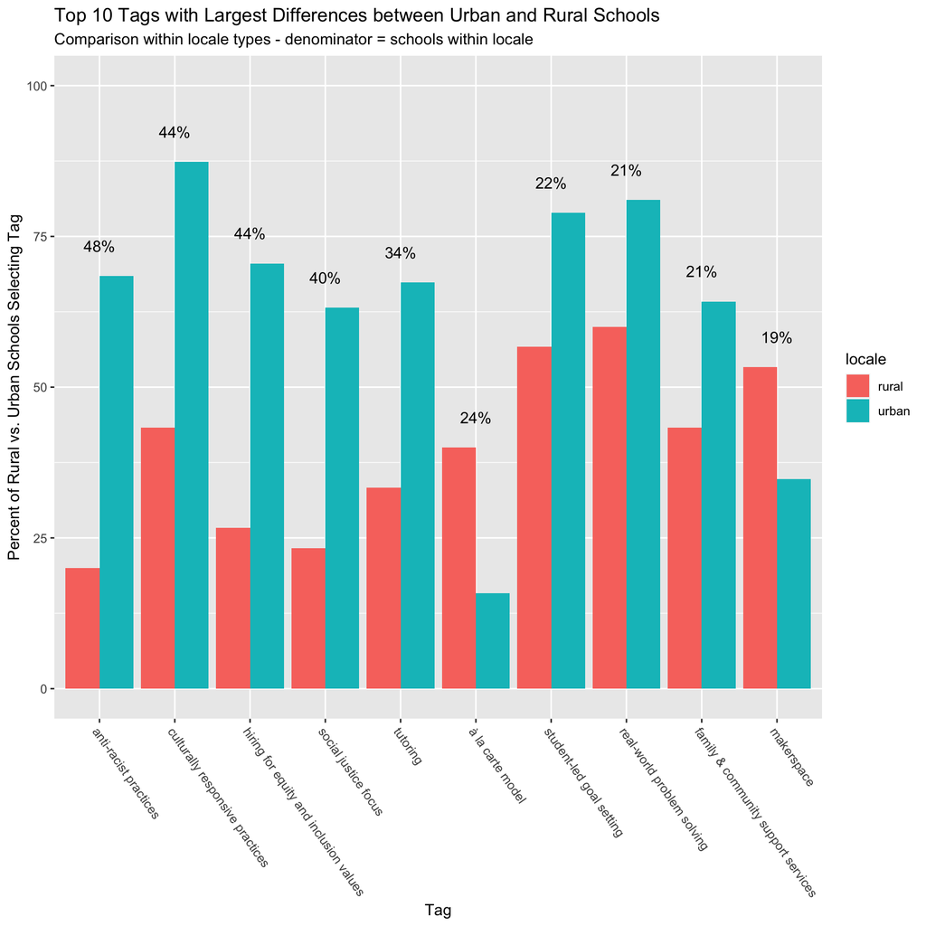

### Urban vs. Suburban (Within)

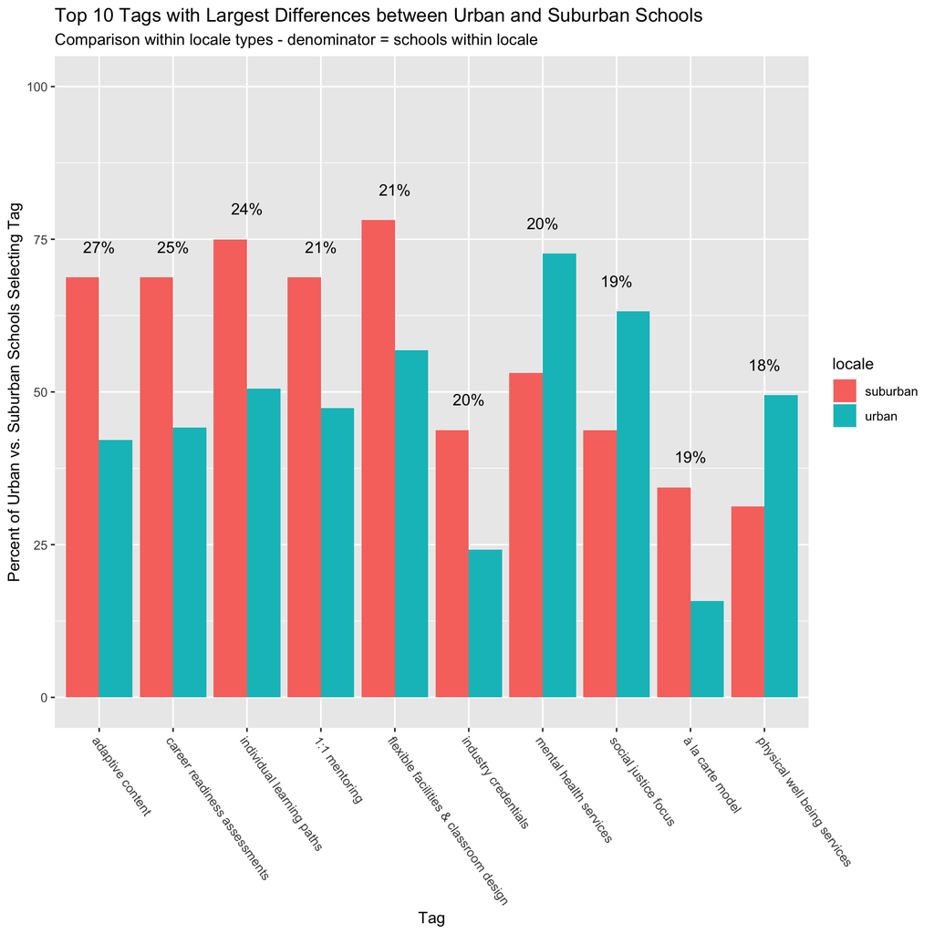

### Suburban vs. Rural (Within)

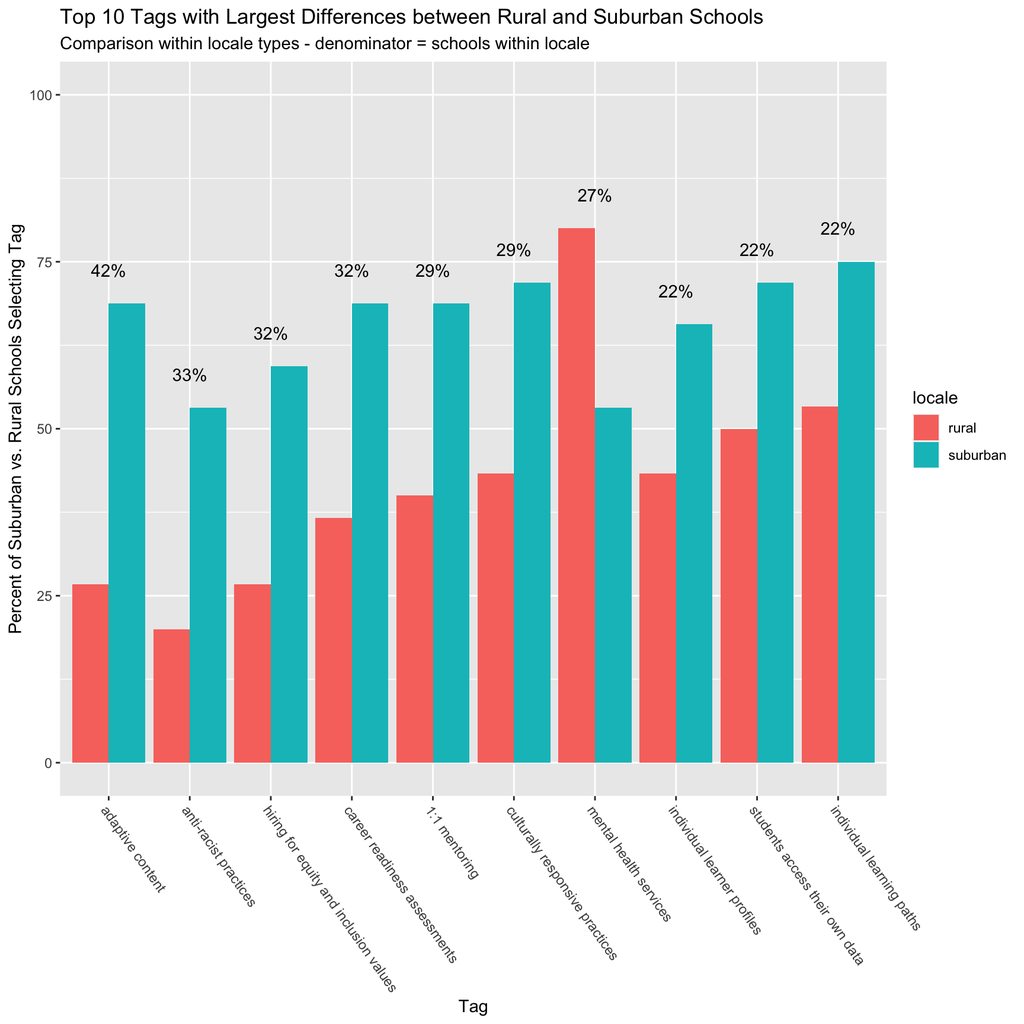

## Probability and Odds Ratios

In this final analysis, I calculated probability for each practice and converted to odds ratio in order to plot how much more or less likely a given locale was to select each tag.

### Urban vs. Rural (Odd Ratio)

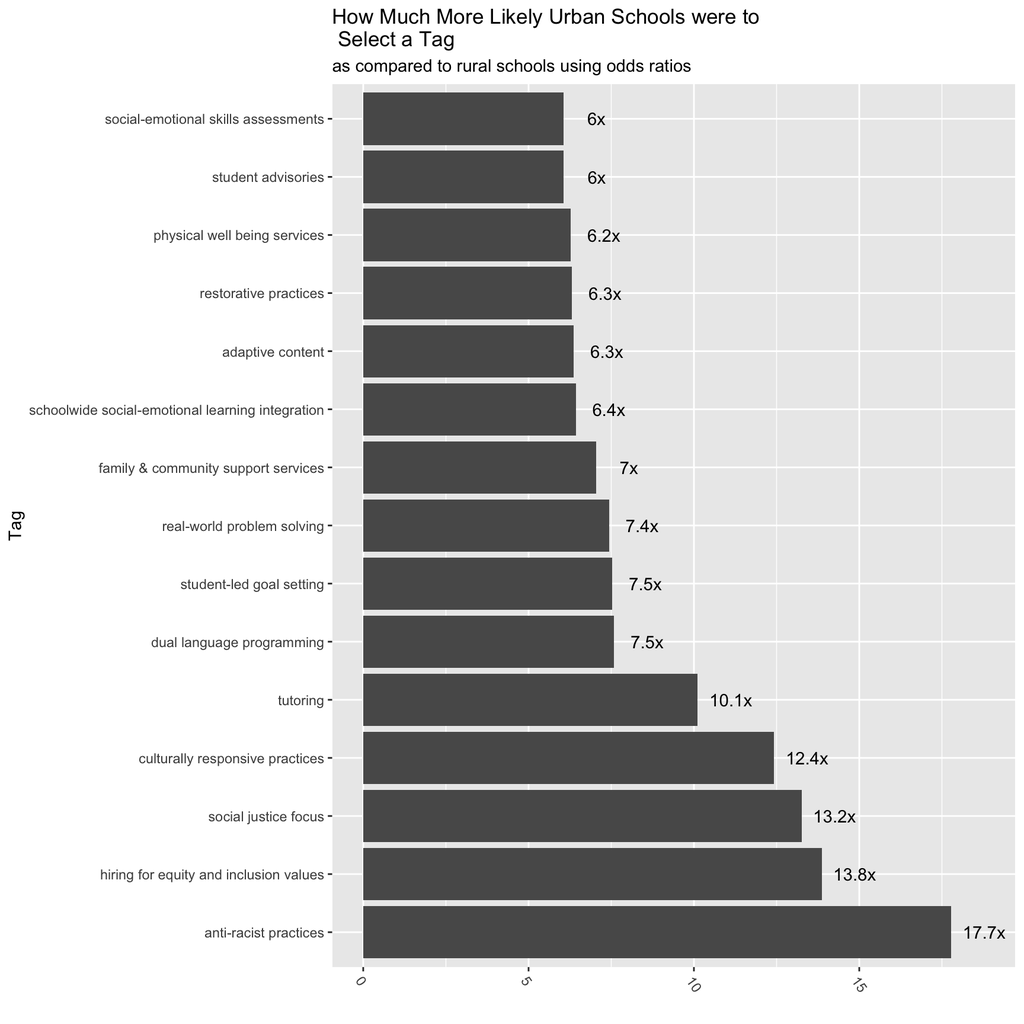